# Cw9_25

### Uogólnione modele liniowe (GLM)

W tradycyjnej regresji liniowej

$Y = a_nX_n+...+a_1X_1+a_0+\epsilon$, gdzie $\epsilon \sim N(0, \sigma)$

albo inaczej

$Y|X \sim N(\mu, \sigma)$, gdzie $\mu = a_nX_n+...+a_1X_1+a_0$

GLM = Generalized Linear Models (Uogólnione modele liniowe)

$Y|X \sim F(\theta)$

$h(\mu) = X \beta$

, gdzie $h$ to tzw. funkcja wiążąca

### Regresja logistyczna

$Y|X \sim B(1,p)$

$\ln(\frac{p}{1-p}) = X\beta$

lub inaczej

$p = \frac{1}{1+e^{-X\beta}}$

- Przewidujemy prawdopodobieństwo wystąpienia jednej z kategorii na podstawie zmiennych objaśniających.

#### Przykład1

```r
dane = read.table("http://www.biecek.pl/R/dane/dane0.csv", sep = ";", header = T)
head(dane)
```

A data.frame: 6 × 9

|  | Wiek <int> | Rozmiar.guza <int> | Wezly.chlonne <int> | Nowotwor <int> | Receptory.estrogenowe <chr> | Receptory.progesteronowe <chr> | Niepowodzenia <chr> | Okres.bez.wznowy <int> | VEGF <int> |
| --- | --- | --- | --- | --- | --- | --- | --- | --- | --- |
| 1 | 29 | 1 | 0 | 2 | (-) | (++) | brak | 22 | 914 |
| 2 | 29 | 1 | 0 | 2 | (++) | (++) | brak | 53 | 1118 |
| 3 | 30 | 1 | 1 | 2 | (-) | (+) | brak | 38 | 630 |
| 4 | 32 | 1 | 0 | 3 | (++) | (++) | brak | 26 | 1793 |
| 5 | 32 | 2 | 0 | NA | (-) | (++) | brak | 19 | 963 |
| 6 | 33 | 1 | 1 | 3 | (-) | (++) | wznowa | 36 | 2776 |

```r
dane$Niepowodzenia = factor(dane$Niepowodzenia)
```

```r
summary(dane)
```

```
      Wiek        Rozmiar.guza   Wezly.chlonne       Nowotwor
 Min.   :29.00   Min.   :1.000   Min.   :0.0000   Min.   :1.000
 1st Qu.:42.00   1st Qu.:1.000   1st Qu.:0.0000   1st Qu.:2.000
 Median :46.00   Median :1.000   Median :0.0000   Median :2.000
 Mean   :45.52   Mean   :1.268   Mean   :0.4124   Mean   :2.221
 3rd Qu.:50.00   3rd Qu.:2.000   3rd Qu.:1.0000   3rd Qu.:3.000
 Max.   :57.00   Max.   :2.000   Max.   :1.0000   Max.   :3.000
                                                  NA's   :11
 Receptory.estrogenowe Receptory.progesteronowe Niepowodzenia Okres.bez.wznowy
 Length:97             Length:97                brak  :84     Min.   :10.00
 Class :character      Class :character         wznowa:13     1st Qu.:30.75
 Mode  :character      Mode  :character                       Median :38.00
                                                              Mean   :37.41
                                                              3rd Qu.:45.00
                                                              Max.   :54.00
                                                              NA's   :1
      VEGF
 Min.   :  118
 1st Qu.:  629
 Median : 1489
 Mean   : 2627
 3rd Qu.: 3240
 Max.   :22554
```

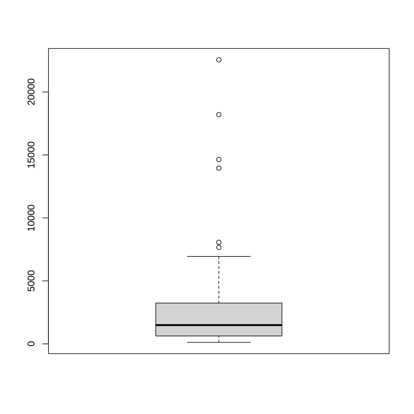

```r
options(repr.plot.width=7, repr.plot.height=7)
boxplot(dane$VEGF)
```

```r
model = glm(Niepowodzenia~Nowotwor+log(VEGF), dane, family = "binomial") #VEGF warto zlogarytmowac (patrz wyzej)
summary(model)
```

```
Call:
glm(formula = Niepowodzenia ~ Nowotwor + log(VEGF), family = "binomial",
    data = dane)

Coefficients:
            Estimate Std. Error z value Pr(>|z|)
(Intercept) -17.3914     4.3757  -3.975 7.05e-05 ***
Nowotwor      2.2586     0.7657   2.950  0.00318 **
log(VEGF)     1.3293     0.4250   3.128  0.00176 **
---
Signif. codes:  0 ‘***’ 0.001 ‘**’ 0.01 ‘*’ 0.05 ‘.’ 0.1 ‘ ’ 1

(Dispersion parameter for binomial family taken to be 1)

    Null deviance: 73.052  on 85  degrees of freedom
Residual deviance: 47.152  on 83  degrees of freedom
  (11 observations deleted due to missingness)
AIC: 53.152

Number of Fisher Scoring iterations: 6
```

```r
tapply(model$fitted.values, model$y, mean)
```

**0**

0.0975060723956273

**1**

0.45246590119919

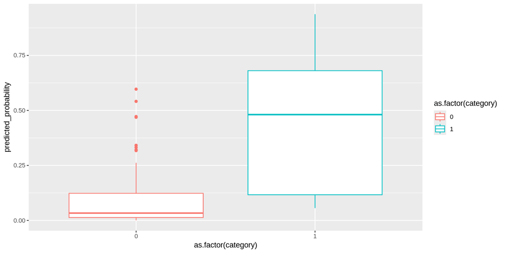

```r
library(ggplot2)
options(repr.plot.width=10, repr.plot.height=5)

ggplot(data.frame(predicted_probability=model$fitted.values, category=model$y)) +
    geom_boxplot(aes(x=as.factor(category), y=predicted_probability, color=as.factor(category)))
```

Domyślnie przyjmujemy $y=1$ gdy wartość prawdopodobieńtwa przekroczy 0.5.

```r
knitr::kable(table(model$y, model$fitted.values>0.5)) #domyslnie pc = 0.5
```

```
|   | FALSE| TRUE|
|:--|-----:|----:|
|0  |    71|    2|
|1  |     7|    6|
```

```r
(71+6)/(71+2+7+6) #dokladnosc
```

0.895348837209302

#### Pytanie: Sterując punktem odcięcia $p_c$ (rozważ 0, 0.5 oraz 0.99), sprawdź jak zmienia się czułość i specyficzność. Skomentuj otrzymane wyniki.

Dla przypomnienia, czułość to $\frac{TP}{TP+FN}$ a specyficzność to $\frac{TN}{TN+FP}$.

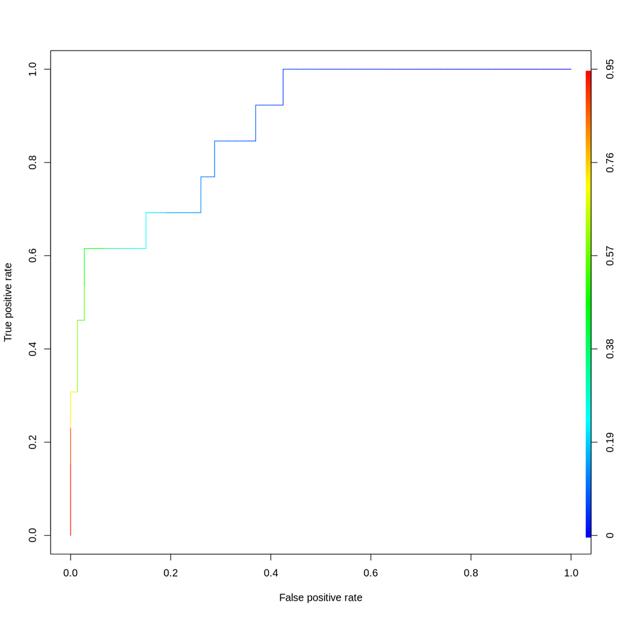

```r
library(ROCR)
roc = prediction(model$fitted.values, model$y)
roc = performance(roc, "tpr", "fpr") #tpr = true poisitive rate

options(repr.plot.width=10, repr.plot.height=10)
plot(roc, colorize=TRUE) #zaleznosc: czulosc vs 1-specyficznosc
```

```r
predykcja = predict(model, newdata = data.frame("Nowotwor" = c(2), "VEGF"=c(914)), type = "response")
predykcja
```

**1:** 0.0216378277633874

#### Pytanie: Wyjaśnij (poprzez bezpośrednie obliczenia, korzystając z wyników w summary(model)) uzyskaną powyżej wartość.

#### Przykład2

```r
white = read.csv("https://tinyurl.com/winedata1", sep = ";")
red = read.csv("https://tinyurl.com/winedata2", sep = ";")
```

```r
white$type = "white"
red$type = "red"

wine = rbind(white, red)
wine$type = factor(wine$type)

head(wine)
```

A data.frame: 6 × 13

|  | fixed.acidity <dbl> | volatile.acidity <dbl> | citric.acid <dbl> | residual.sugar <dbl> | chlorides <dbl> | free.sulfur.dioxide <dbl> | total.sulfur.dioxide <dbl> | density <dbl> | pH <dbl> | sulphates <dbl> | alcohol <dbl> | quality <int> | type <fct> |
| --- | --- | --- | --- | --- | --- | --- | --- | --- | --- | --- | --- | --- | --- |
| 1 | 7.0 | 0.27 | 0.36 | 20.7 | 0.045 | 45 | 170 | 1.0010 | 3.00 | 0.45 | 8.8 | 6 | white |
| 2 | 6.3 | 0.30 | 0.34 | 1.6 | 0.049 | 14 | 132 | 0.9940 | 3.30 | 0.49 | 9.5 | 6 | white |
| 3 | 8.1 | 0.28 | 0.40 | 6.9 | 0.050 | 30 | 97 | 0.9951 | 3.26 | 0.44 | 10.1 | 6 | white |
| 4 | 7.2 | 0.23 | 0.32 | 8.5 | 0.058 | 47 | 186 | 0.9956 | 3.19 | 0.40 | 9.9 | 6 | white |
| 5 | 7.2 | 0.23 | 0.32 | 8.5 | 0.058 | 47 | 186 | 0.9956 | 3.19 | 0.40 | 9.9 | 6 | white |
| 6 | 8.1 | 0.28 | 0.40 | 6.9 | 0.050 | 30 | 97 | 0.9951 | 3.26 | 0.44 | 10.1 | 6 | white |

```r
summary(wine)
```

```
 fixed.acidity    volatile.acidity  citric.acid     residual.sugar
 Min.   : 3.800   Min.   :0.0800   Min.   :0.0000   Min.   : 0.600
 1st Qu.: 6.400   1st Qu.:0.2300   1st Qu.:0.2500   1st Qu.: 1.800
 Median : 7.000   Median :0.2900   Median :0.3100   Median : 3.000
 Mean   : 7.215   Mean   :0.3397   Mean   :0.3186   Mean   : 5.443
 3rd Qu.: 7.700   3rd Qu.:0.4000   3rd Qu.:0.3900   3rd Qu.: 8.100
 Max.   :15.900   Max.   :1.5800   Max.   :1.6600   Max.   :65.800
   chlorides       free.sulfur.dioxide total.sulfur.dioxide    density
 Min.   :0.00900   Min.   :  1.00      Min.   :  6.0        Min.   :0.9871
 1st Qu.:0.03800   1st Qu.: 17.00      1st Qu.: 77.0        1st Qu.:0.9923
 Median :0.04700   Median : 29.00      Median :118.0        Median :0.9949
 Mean   :0.05603   Mean   : 30.53      Mean   :115.7        Mean   :0.9947
 3rd Qu.:0.06500   3rd Qu.: 41.00      3rd Qu.:156.0        3rd Qu.:0.9970
 Max.   :0.61100   Max.   :289.00      Max.   :440.0        Max.   :1.0390
       pH          sulphates         alcohol         quality         type
 Min.   :2.720   Min.   :0.2200   Min.   : 8.00   Min.   :3.000   red  :1599
 1st Qu.:3.110   1st Qu.:0.4300   1st Qu.: 9.50   1st Qu.:5.000   white:4898
 Median :3.210   Median :0.5100   Median :10.30   Median :6.000
 Mean   :3.219   Mean   :0.5313   Mean   :10.49   Mean   :5.818
 3rd Qu.:3.320   3rd Qu.:0.6000   3rd Qu.:11.30   3rd Qu.:6.000
 Max.   :4.010   Max.   :2.0000   Max.   :14.90   Max.   :9.000
```

```r
m = glm(type ~ pH + alcohol, data = wine, family = "binomial")
summary(m)
```

```
Call:
glm(formula = type ~ pH + alcohol, family = "binomial", data = wine)

Coefficients:
            Estimate Std. Error z value Pr(>|z|)
(Intercept) 16.39466    0.69282   23.66  < 2e-16 ***
pH          -5.25833    0.20858  -25.21  < 2e-16 ***
alcohol      0.17211    0.02723    6.32 2.61e-10 ***
---
Signif. codes:  0 ‘***’ 0.001 ‘**’ 0.01 ‘*’ 0.05 ‘.’ 0.1 ‘ ’ 1

(Dispersion parameter for binomial family taken to be 1)

    Null deviance: 7251.0  on 6496  degrees of freedom
Residual deviance: 6493.3  on 6494  degrees of freedom
AIC: 6499.3

Number of Fisher Scoring iterations: 4
```

```r
levels(wine$type) #biale jest w drugiej klasie
```

1. 'red'

2. 'white'

```r
confint(m) #standardowa metoda z lm do oszacowania przedzialow ufnosci na parametry
```

A matrix: 3 × 2 of type dbl

|  | 2.5 % | 97.5 % |
| --- | --- | --- |
| (Intercept) | 15.0471103 | 17.7633691 |
| pH | -5.6705511 | -4.8527787 |
| alcohol | 0.1189972 | 0.2257619 |

```r
library(boot.pval)
boot_summary(m, type = "perc", method = "case") #przedzial ufnosci na parametry metodą bootstrap
```

A data.frame: 3 × 4

|  | Estimate <dbl> | Lower.bound <dbl> | Upper.bound <dbl> | p.value <chr> |
| --- | --- | --- | --- | --- |
| (Intercept) | 16.3946592 | 15.0691561 | 17.8063819 | <0.001 |
| pH | -5.2583338 | -5.6990448 | -4.8484778 | <0.001 |
| alcohol | 0.1721121 | 0.1189408 | 0.2272615 | <0.001 |

Uwaga: Znacząco trudniej jest dokonać diagnostyki modeli GLM gdyż reszty zachowują się odmiennie niz w regresji liniowej.

#### Zadanie1: Rozważ dane "SAheart"

```r
library(bestglm)
data("SAheart")
head(SAheart) #chd - czy występuje choroba niedokrwienna serca, warto poczytac o danych ?`
```

A data.frame: 6 × 10

|  | sbp <int> | tobacco <dbl> | ldl <dbl> | adiposity <dbl> | famhist <fct> | typea <int> | obesity <dbl> | alcohol <dbl> | age <int> | chd <int> |
| --- | --- | --- | --- | --- | --- | --- | --- | --- | --- | --- |
| 1 | 160 | 12.00 | 5.73 | 23.11 | Present | 49 | 25.30 | 97.20 | 52 | 1 |
| 2 | 144 | 0.01 | 4.41 | 28.61 | Absent | 55 | 28.87 | 2.06 | 63 | 1 |
| 3 | 118 | 0.08 | 3.48 | 32.28 | Present | 52 | 29.14 | 3.81 | 46 | 0 |
| 4 | 170 | 7.50 | 6.41 | 38.03 | Present | 51 | 31.99 | 24.26 | 58 | 1 |
| 5 | 134 | 13.60 | 3.50 | 27.78 | Present | 60 | 25.99 | 57.34 | 49 | 1 |
| 6 | 132 | 6.20 | 6.47 | 36.21 | Present | 62 | 30.77 | 14.14 | 45 | 0 |

```r
str(SAheart)
```

```
'data.frame':	462 obs. of  10 variables:
 $ sbp      : int  160 144 118 170 134 132 142 114 114 132 ...
 $ tobacco  : num  12 0.01 0.08 7.5 13.6 6.2 4.05 4.08 0 0 ...
 $ ldl      : num  5.73 4.41 3.48 6.41 3.5 6.47 3.38 4.59 3.83 5.8 ...
 $ adiposity: num  23.1 28.6 32.3 38 27.8 ...
 $ famhist  : Factor w/ 2 levels "Absent","Present": 2 1 2 2 2 2 1 2 2 2 ...
 $ typea    : int  49 55 52 51 60 62 59 62 49 69 ...
 $ obesity  : num  25.3 28.9 29.1 32 26 ...
 $ alcohol  : num  97.2 2.06 3.81 24.26 57.34 ...
 $ age      : int  52 63 46 58 49 45 38 58 29 53 ...
 $ chd      : int  1 1 0 1 1 0 0 1 0 1 ...
```

#### Zbuduj model regresji logistycznej, progonzując $chd$ tylko w oparciu o $ldl$ (model1). Zbuduj model regresji logistycznej, prognozująć $chd$ w oparciu o wszystkie pozostałe zmienne (model2). Za pomocą kryterium AIC i F testu (w poleceniu anova dodaj argument: test = "LRT") porównaj modele. Skomentuj wyniki. Z użyciem polecenia $step$ (bierze pod uwagę kryterium AIC) zredukuj pełny model (model2). Składnia: step(model, trace=0) <- tworzony jest nowy model (model3). Za pomocą F testu porównaj model2 oraz model3. Skomentuj otrzymane wyniki. Dla każdego z modeli oblicz dokładność oraz czułość/specyficzność Dokonaj predykcji (za pomocą wszystkich modeli) dla osobnika o parametrach identycznych jak w pierwszym rekordzie. Skomentuj otrzymane wyniki.

### Regresja Poissonowska

$Y|X \sim Poiss (\lambda)$

$\log (\lambda) = X\beta$

Modelujemy dane zliczeniowe. Naczelne założenie, to $\overline{Y} \approx S^2(Y)$.

Jeżeli $Y \sim Poiss(\lambda)$, to $P(Y = k ) = \frac{e^{-\lambda}\lambda^k}{k!}$

Cel: Znaleźć $\lambda$. Ta będzie zależeć od zmiennych objaśniających. Domyślnie zakładamy następującą postać: $\lambda = e^{a_nx_n+a_nx_n+...+a_0}$ albo inaczej $\log(\lambda) = a^Tx$ (logarytm jest funkcją łączącą).

```r
set.seed(1)
n = 100
y1 = rpois(n, 3)
y2 = rpois(n, 6)
d = data.frame(x = c(rep("A",n),rep("B",n)), y = c(y1,y2))

head(d)
```

A data.frame: 6 × 2

|  | x <chr> | y <int> |
| --- | --- | --- |
| 1 | A | 2 |
| 2 | A | 2 |
| 3 | A | 3 |
| 4 | A | 5 |
| 5 | A | 2 |
| 6 | A | 5 |

```r
print(tapply(d$y, d$x, mean))
```

```
   A    B
3.05 6.16
```

```r
summary(model <- glm(y ~ x, family="poisson", data = d))
```

```
Call:
glm(formula = y ~ x, family = "poisson", data = d)

Coefficients:
            Estimate Std. Error z value Pr(>|z|)
(Intercept)  1.11514    0.05726   19.48   <2e-16 ***
xB           0.70294    0.07001   10.04   <2e-16 ***
---
Signif. codes:  0 ‘***’ 0.001 ‘**’ 0.01 ‘*’ 0.05 ‘.’ 0.1 ‘ ’ 1

(Dispersion parameter for poisson family taken to be 1)

    Null deviance: 267.98  on 199  degrees of freedom
Residual deviance: 160.87  on 198  degrees of freedom
AIC: 812.91

Number of Fisher Scoring iterations: 4
```

Wyjaśnienie tych współczynników:

```r
exp(1.11514) #lambda dla A
```

3.04999514861493

```r
exp(1.11514+0.70294) #lambda dla B
```

6.16001985035215

#### Praktyczny przykład

```r
p =  read.csv("https://stats.idre.ucla.edu/stat/data/poisson_sim.csv")
head(p)
```

A data.frame: 6 × 4

|  | id <int> | num_awards <int> | prog <int> | math <int> |
| --- | --- | --- | --- | --- |
| 1 | 45 | 0 | 3 | 41 |
| 2 | 108 | 0 | 1 | 41 |
| 3 | 15 | 0 | 3 | 44 |
| 4 | 67 | 0 | 3 | 42 |
| 5 | 153 | 0 | 3 | 40 |
| 6 | 51 | 0 | 1 | 42 |

```r
p = within(p, {
            prog = factor(prog, levels=1:3, labels=c("General", "Academic", "Vocational"))
            id = factor(id)
})
head(p)
```

A data.frame: 6 × 4

|  | id <fct> | num_awards <int> | prog <fct> | math <int> |
| --- | --- | --- | --- | --- |
| 1 | 45 | 0 | Vocational | 41 |
| 2 | 108 | 0 | General | 41 |
| 3 | 15 | 0 | Vocational | 44 |
| 4 | 67 | 0 | Vocational | 42 |
| 5 | 153 | 0 | Vocational | 40 |
| 6 | 51 | 0 | General | 42 |

```r
summary(p)
```

```
       id        num_awards           prog          math
 1      :  1   Min.   :0.00   General   : 45   Min.   :33.00
 2      :  1   1st Qu.:0.00   Academic  :105   1st Qu.:45.00
 3      :  1   Median :0.00   Vocational: 50   Median :52.00
 4      :  1   Mean   :0.63                    Mean   :52.65
 5      :  1   3rd Qu.:1.00                    3rd Qu.:59.00
 6      :  1   Max.   :6.00                    Max.   :75.00
 (Other):194
```

```r
with(p, tapply(num_awards, prog, function(x) { sprintf("srednia (wariancja) = %1.2f (%1.2f)", mean(x), var(x))}))
```

**General**

'srednia (wariancja) = 0.20 (0.16)'

**Academic**

'srednia (wariancja) = 1.00 (1.63)'

**Vocational**

'srednia (wariancja) = 0.24 (0.27)'

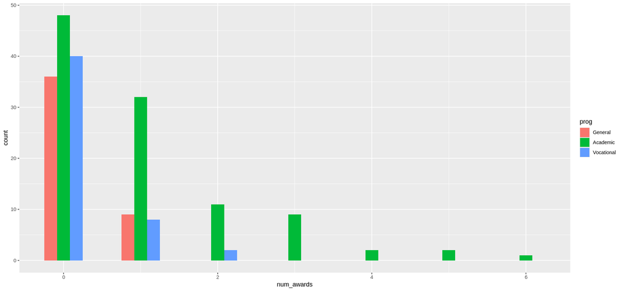

```r
library(ggplot2)
options(repr.plot.width=15, repr.plot.height=7)

ggplot(p, aes(num_awards, fill = prog)) +
  geom_histogram(binwidth=.5, position="dodge")
```

```r
m1 =  glm(num_awards ~ prog + math, family="poisson", data=p)
summary(m1)
```

```
Call:
glm(formula = num_awards ~ prog + math, family = "poisson", data = p)

Coefficients:
               Estimate Std. Error z value Pr(>|z|)
(Intercept)    -5.24712    0.65845  -7.969 1.60e-15 ***
progAcademic    1.08386    0.35825   3.025  0.00248 **
progVocational  0.36981    0.44107   0.838  0.40179
math            0.07015    0.01060   6.619 3.63e-11 ***
---
Signif. codes:  0 ‘***’ 0.001 ‘**’ 0.01 ‘*’ 0.05 ‘.’ 0.1 ‘ ’ 1

(Dispersion parameter for poisson family taken to be 1)

    Null deviance: 287.67  on 199  degrees of freedom
Residual deviance: 189.45  on 196  degrees of freedom
AIC: 373.5

Number of Fisher Scoring iterations: 6
```

```r
library(sandwich)

#tzw robust standard errors (nieco lepsze niz standardowe bledy jezeli naruszone jest zalozenie ze wariancja jest rowna sredniej)
macierz_kowariancji = vcovHC(m1, type="HC0")
odchylenia = sqrt(diag(macierz_kowariancji))
podsumowanie = cbind(Estimate= coef(m1), "Robust SE" = odchylenia,
               "Pr(>|z|)" = 2 * pnorm(abs(coef(m1)/odchylenia), lower.tail=FALSE), #dodaje tez wartosci p_value
                LL = coef(m1) - 1.96 * odchylenia,  #95% przedzial ufnosci, z dolu
                UL = coef(m1) + 1.96 * odchylenia)  #95% przedzial ufnosci, z gory

print(podsumowanie)
```

```
                 Estimate  Robust SE     Pr(>|z|)          LL          UL
(Intercept)    -5.2471244 0.64599839 4.566630e-16 -6.51328124 -3.98096756
progAcademic    1.0838591 0.32104816 7.354745e-04  0.45460476  1.71311353
progVocational  0.3698092 0.40041731 3.557157e-01 -0.41500870  1.15462716
math            0.0701524 0.01043516 1.783975e-11  0.04969947  0.09060532
```

#### Zadanie2: Na podstawie powyższego podsumowania określ średni poziom uzyskanych nagród dla studenta w programie Academic z wynikiem z testu 50. Ile wg modelu wynosi prawdopodobieństwo uzyskania dwóch nagród w tej sytuacji?

```r
#zobaczmy jakby to wygladalo dla wszystkich programow
s1 = data.frame(math = 50, prog = factor(1:3, levels = 1:3, labels = levels(p$prog)))
s1
```

A data.frame: 3 × 2

| math <dbl> | prog <fct> |
| --- | --- |
| 50 | General |
| 50 | Academic |
| 50 | Vocational |

```r
predict(m1, s1, type="response", se.fit=TRUE)
```

**$fit**

**1**

0.17560738833725

**2**

0.519106934141021

**3**

0.254184399262976

**$se.fit**

**1**

0.0589126683735189

**2**

0.0826062745991759

**3**

0.0737200378790345

**$residual.scale**

1

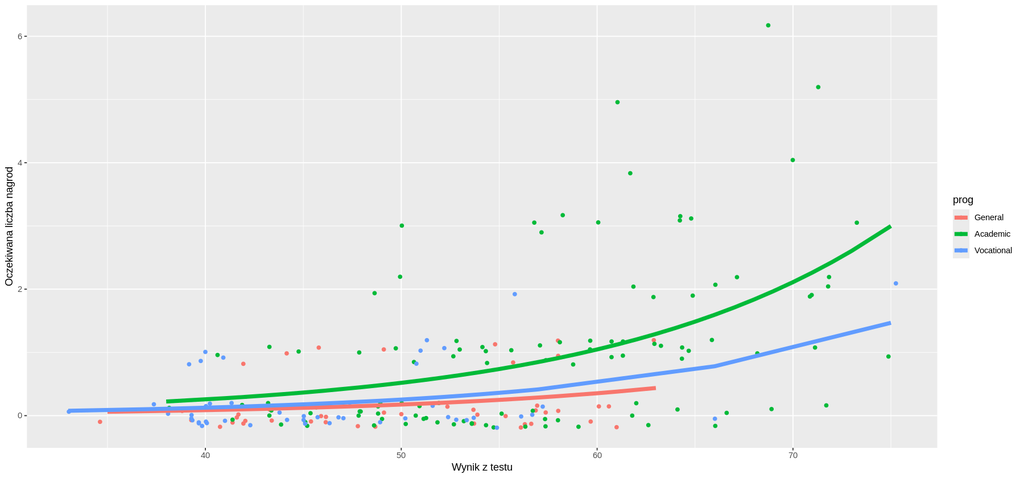

```r
## i zbiorczo
## predykcja
p$phat = predict(m1, p[, c("math", "prog")], type = "response")

## porzadkujemy wg programu a potem wg testu z matematyki
p = p[with(p, order(prog, math)), ]

## wykres
ggplot(p, aes(x = math, y = phat, colour = prog)) +
       geom_point(aes(y = num_awards), alpha=2, position=position_jitter(h=.2)) +
       geom_line(linewidth = 2) +
       labs(x = "Wynik z testu", y = "Oczekiwana liczba nagrod")
```

### Regresja z rozkładem ujemnym dwumianowym

- Jeżeli wariancje nie są równe wartościom oczekiwanym, to stosowanie regresji Poissona może prowadzić do niepoprawnego modelu. Warto wtedy zastosować rozkład ujemny dwumianowy, dla którego: $var(X) = \mu + \mu^2/\theta$.

```r
library(MASS)
nb.model <- glm.nb(num_awards ~ prog + math, data=p) #Regresja z rozkładem ujemnym dwumianowym
summary(nb.model) #wzrosly błędy, wspolczynniki zasadniczo te same
```

```
Call:
glm.nb(formula = num_awards ~ prog + math, data = p, init.theta = 6.114661779,
    link = log)

Coefficients:
               Estimate Std. Error z value Pr(>|z|)
(Intercept)    -5.29331    0.70416  -7.517 5.60e-14 ***
progAcademic    1.07507    0.36699   2.929   0.0034 **
progVocational  0.36696    0.45230   0.811   0.4172
math            0.07107    0.01153   6.165 7.05e-10 ***
---
Signif. codes:  0 ‘***’ 0.001 ‘**’ 0.01 ‘*’ 0.05 ‘.’ 0.1 ‘ ’ 1

(Dispersion parameter for Negative Binomial(6.1147) family taken to be 1)

    Null deviance: 257.93  on 199  degrees of freedom
Residual deviance: 169.76  on 196  degrees of freedom
AIC: 373.81

Number of Fisher Scoring iterations: 1


              Theta:  6.11
          Std. Err.:  5.58

 2 x log-likelihood:  -363.811
```

#### Zadanie3: Rozważ dane warpbreaks. Dane opisują wpływ rodzaju wełny (A oraz B) i naprężenia (niskie L, średnie M lub wysokie H) na liczbę zerwań osnowy w krośnie (breaks). Zamodeluj zmienną breaks za pomocą wool oraz tension wykorzystując przy tym regresję poissona oraz ujemną dwumianową (zbuduj dwa modele). Porównaj istotność statystyczną wyestymowanych parametrów w obu modelach. Zinterpretuj wyraz wolny.

#### Zadanie4: Dane "czerniak.txt" przedstawiają surowe zliczenia RNA-seq (ang. raw counts) wybranych genów w 10 próbkach z czerniakiem i w 8 próbkach kontrolnych. Dla każdego genu zbuduj model regresji z rozkładem ujemnym dwumianowym, modelując ekspresję genu na podstawie grupy. Czy wyestymowane współczynniki są istotne statystycznie? Czy istotność statystyczna oznacza istotność biologiczną? Ekspresja których genów zmienia się między grupami? W jaki sposób?